# LSN 9 - ACFT Sled Pull (2.2)

LTC Starling

## Admin

The Center for Data Analysis and Statistics (CDAS) at D/Math USMA was asked to consult on a project with DPE examining the surface that the sled pull was conducted on. They wanted to demonstrate that there was an effect due to the surface. They took 25 volunteers and had them do the sled pull on grass, turf, and sand.

1. Create a sources of variation diagram:

Observed variation in: ACFT sled pull scores (quant, integer values); Sources of explained variation: Surface (categorical, 3 levels); Sources of Unexplained variation: weather (temp/rain/wind/etc), field conditions, person’s attributes (sleep/energy intake/weight/etc); Inclusion criteria: 25 volunteers (cadets/faculty?); Design: have each volunteer conduct the sled pull on each of the three surfaces, with a randomly assigned order.

2. Consider the following boxplot. Explain what you see.

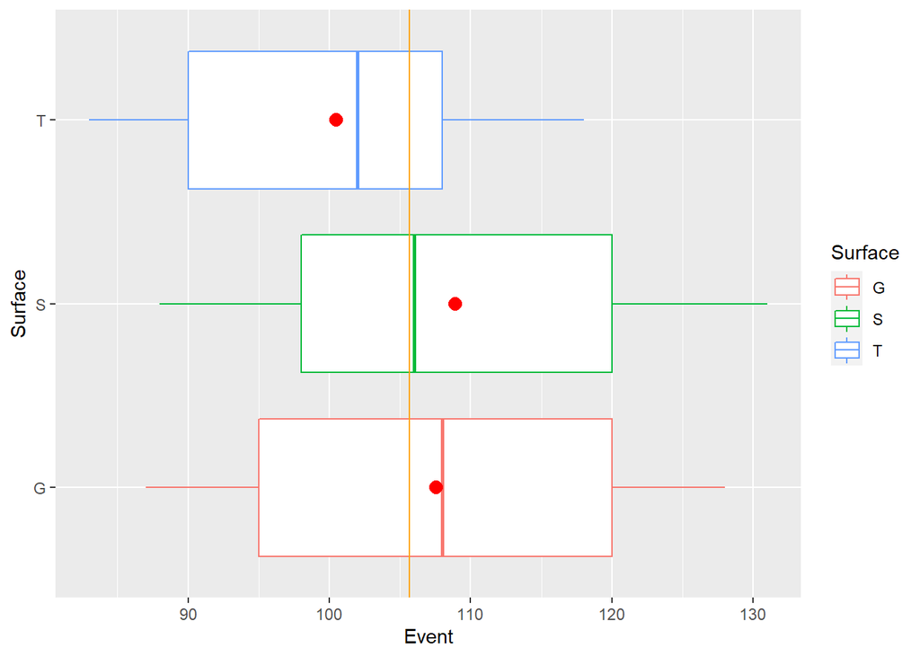

```r
ACFT <- read.csv("https://raw.githubusercontent.com/jkstarling/MA376/main/ACFT.csv", stringsAsFactors = TRUE)
ACFT <- ACFT %>% mutate(Participantf=as.factor(Participant)) %>% arrange(Surface, Participant)

ACFT %>% ggplot(aes(x=Event, y=Surface, col=Surface)) +
  geom_boxplot() + stat_summary(fun=mean, geom="point", shape=20, size=5, color="red", fill="red") + geom_vline(aes(xintercept = mean(Event)), color="orange")
```

3. Consider the following output. Calculate the observed effects for each surface. What is the sum of all effects?

```r
contrasts(ACFT$Surface)=contr.sum
ACFT.mn.sd <- ACFT %>% group_by(Surface) %>%
  summarise(n=n(),mean=mean(Event),sd=sd(Event)); ACFT.mn.sd
```

| Surface | n | mean | sd |
| --- | --- | --- | --- |
| G | 25 | 107.56 | 13.44458 |
| S | 25 | 108.92 | 13.75354 |
| T | 25 | 100.48 | 11.17706 |

```r
event.mn <- mean(ACFT$Event); event.mn
```

```
## [1] 105.6533
```

```r
mydiff <- ACFT.mn.sd$mean - event.mn; mydiff
```

```
## [1]  1.906667  3.266667 -5.173333
```

```r
sum(mydiff)
```

```
## [1] 0
```

4. Consider the ANOVA table. How much variation is explained by Surface? What does the p-value tell us?

```r
single.lm <- ACFT %>% lm(Event~Surface,data = .)
anova(single.lm)
```

|  | Df | Sum Sq | Mean Sq | F value | Pr(>F) |
| --- | --- | --- | --- | --- | --- |
| Surface | 2 | 1026.747 | 513.3733 | 3.112339 | 0.05053518 |
| Residuals | 72 | 11876.240 | 164.9478 | NA | NA |

```r
r.sq <- 1026.7 / (1036.7 + 11876.2); r.sq
```

```
## [1] 0.07950964
```

The amount of variance explained by the model is (r-squared =) 0.079. The p-value is slightly above 5% and we fail to reject the null hypothesis.

5. What other source of variation can we consider?

The effect of each participant on the event scores.

6. Based on the output below, does `participant` seem to matter?

```r
ACFT %>% group_by(Participantf) %>%
  summarise(n=n(),mean=mean(Event),sd=sd(Event)) %>%
  head(10)
```

| Participantf | n | mean | sd |
| --- | --- | --- | --- |
| 1 | 3 | 90.33333 | 1.5275252 |
| 2 | 3 | 86.33333 | 2.0816660 |
| 3 | 3 | 103.00000 | 4.5825757 |
| 4 | 3 | 107.33333 | 5.8594653 |
| 5 | 3 | 114.00000 | 7.2111026 |
| 6 | 3 | 92.66667 | 0.5773503 |
| 7 | 3 | 93.33333 | 4.1633320 |
| 8 | 3 | 97.33333 | 7.0237692 |
| 9 | 3 | 105.33333 | 4.0414519 |
| 10 | 3 | 109.33333 | 5.8594653 |

7. Can we consider this a blocked study design? What is our updated statistical model?

Yes since the scores are ’potentially related to the response variable and is not manipulated by the researcher.

Event score = surface type + participant

8. Consider the simulation below. Calculate the p-value, mean, and standard deviation from this simulation. Does this model take into account blocking?

```r
set.seed(376)
M<-1000
stat <- rep(NA, M)  # create empty vector
for(j in 1:M){
  ACFT$shuffled.cat <- sample(ACFT$Surface)
  shuff.lm <- ACFT %>% lm(Event~shuffled.cat,data=.)
  stat[j] <- anova(shuff.lm)$"F value"[1]
}
```

```r
my.Fstat <- anova(single.lm)$"F value"[1]
sum(stat > my.Fstat)/M
```

```
## [1] 0.051
```

```r
mean(stat)
```

```
## [1] 1.02927
```

```r
sd(stat)
```

```
## [1] 1.10492
```

9. Consider another simulation which takes into account the blocking by participant. What is going on in this code? What happens to the mean/sd of our F distribution? How rare is our F value now? What is our conclusion?

```r
set.seed(376)
M<-1000
stat <- rep(NA, M)  # create empty vector
for(j in 1:M){
  ACFT.mod <- ACFT %>% group_by(Participantf) %>% sample_n(3)
  ACFT.mod$shuffled.cat <- rep(c("S","T","G"),25)
  shuff.lm <- ACFT.mod %>% lm(Event~shuffled.cat,data=.)
  stat[j] <- anova(shuff.lm)$"F value"[1]
}
```

```r
c(sum(stat > my.Fstat)/M, mean(stat), sd(stat))
```

```
## [1] 0.0000000 0.2039404 0.2077850
```

We can conclude that there is a relationship between the three surfaces and sled pull scores, accouting for participant.

10. Calculate the Participant (block) effect for our participants. Did we impose a `sum to zero constraint’?

```r
effects <- ACFT %>% group_by(Participantf) %>%
  summarise(effect=mean(Event)-mean(ACFT$Event)) %>%
  pull(effect)
effects
```

```
##  [1] -15.320000 -19.320000  -2.653333   1.680000   8.346667 -12.986667
##  [7] -12.320000  -8.320000  -0.320000   3.680000   3.680000  10.680000
## [13]  15.013333  15.346667   8.680000   9.013333 -12.986667 -17.653333
## [19] -15.653333  16.346667  19.346667   4.680000  -8.653333  18.013333
## [25]  -8.320000
```

```r
sum(effects)
```

```
## [1] -9.947598e-14
```

Yes, we added a zero sum constraint (this number is essentially mechanical zero)

11. Consider the adjusted surface effects below. How does the variance of the block-adjusted values compare to the original values? Do the group means change?

```r
adj.effect <- ACFT %>% mutate(person.means = rep(effects,3)) %>%
  mutate(adjeffect = Event-person.means)
var(adj.effect$adjeffect)
```

```
## [1] 24.63964
```

```r
var(ACFT$Event)
```

```
## [1] 174.3647
```

```r
adj.effect %>% group_by(Surface) %>% summarise(means=mean(adjeffect),sd=sd(adjeffect))
```

| Surface | means | sd |
| --- | --- | --- |
| G | 107.56 | 3.433927 |
| S | 108.92 | 3.323597 |
| T | 100.48 | 3.217602 |

The variance of the block-adjusted values is much less than the original values. The means remain the same, but the standard deviations are reduced.

12. Our block-adjusted F-statistic and simulated F-statistics are given below. Calculate the p-value for the simulation. What do you notice about the values in the row associated with the `Participantf` variable?

```r
adj.mod <- lm(adjeffect ~ Surface + Participantf, data = adj.effect)
anova(adj.mod)
```

|  | Df | Sum Sq | Mean Sq | F value | Pr(>F) |
| --- | --- | --- | --- | --- | --- |
| Surface | 2 | 1.026747e+03 | 5.133733e+02 | 3.093439e+01 | 2.337798e-09 |
| Participantf | 24 | 1.754879e-26 | 7.311995e-28 | 4.405996e-29 | 1.000000e+00 |
| Residuals | 48 | 7.965867e+02 | 1.659556e+01 | NA | NA |

```r
set.seed(376)
M<-1000
stat <- rep(NA, M)  # create empty vector
for(j in 1:M){
  adj.effect$shuffled.cat <- sample(adj.effect$Surface)
  shuff.lm <- adj.effect %>% lm(adjeffect ~ shuffled.cat + Participantf, data=.)
  stat[j] <- anova(shuff.lm)$"F value"[1]
}
```

```r
my.Fstat <- anova(adj.mod)$'F value'[1]
sum(stat > my.Fstat) / M
```

```
## [1] 0
```

The estimated p-value is 0. We can see that the row associated with the Participantf variable only has 0’s in it. (we have removed the variance by adjusting for the participant effects).

13. Are validity conditions met for using F-distribution for our F statistic in this study? Why/why not?

1. Sample sizes are at least 20 per group with no strong skewness (see box plot above).

2. Standard deviations of the adjusted response are approximately equal to each other.

3. The experimental units (the participants) were randomly assigned to the treatments (surfaces) in each block (the participants).

14. Compare the ANOVA Table for the model with blocking with the ANOVA table from the adjusted model and the original model. What do you notice about the SST for each model? What about the MSE? ($MSE=\frac{SSE}{df}$)

```r
full.lm<-lm(Event~Surface+Participantf,data=ACFT)
anova(full.lm)
```

|  | Df | Sum Sq | Mean Sq | F value | Pr(>F) |
| --- | --- | --- | --- | --- | --- |
| Surface | 2 | 1026.7467 | 513.37333 | 30.93439 | 2.337798e-09 |
| Participantf | 24 | 11079.6533 | 461.65222 | 27.81782 | 1.380038e-20 |
| Residuals | 48 | 796.5867 | 16.59556 | NA | NA |

```r
anova(adj.mod)
```

|  | Df | Sum Sq | Mean Sq | F value | Pr(>F) |
| --- | --- | --- | --- | --- | --- |
| Surface | 2 | 1.026747e+03 | 5.133733e+02 | 3.093439e+01 | 2.337798e-09 |
| Participantf | 24 | 1.754879e-26 | 7.311995e-28 | 4.405996e-29 | 1.000000e+00 |
| Residuals | 48 | 7.965867e+02 | 1.659556e+01 | NA | NA |

```r
anova(single.lm)
```

|  | Df | Sum Sq | Mean Sq | F value | Pr(>F) |
| --- | --- | --- | --- | --- | --- |
| Surface | 2 | 1026.747 | 513.3733 | 3.112339 | 0.05053518 |
| Residuals | 72 | 11876.240 | 164.9478 | NA | NA |

15. So, should we always block? If we create blocks and there are no true block effects, what happens to our F statistic?

In the best case scenario we have decreased the numerator of $MSE=\frac{SSE}{df}$ by enough to offset the loss of $df$ in the denominator. As a rule of thumb before blocking you should, a-priori, think about the variation in our response and consider whether it makes logical sense that variation in our blocks would impact the variability in our response. You cannot be wrong though if your statistical model reflects your experiment. If you randomized within block you should build a model that contains blocks.